# Final Project: Predictive Modeling of Mice Neural Activity in Response to Visual Stimuli

### Neuron activity

We want to know about neuron activity in each trial so we extract spikes and time from single trials and create raster plot.

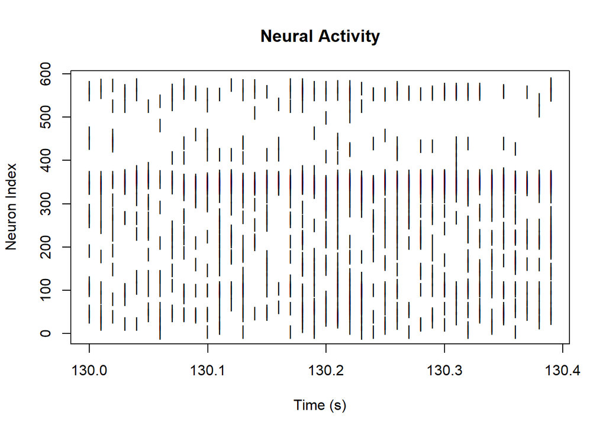

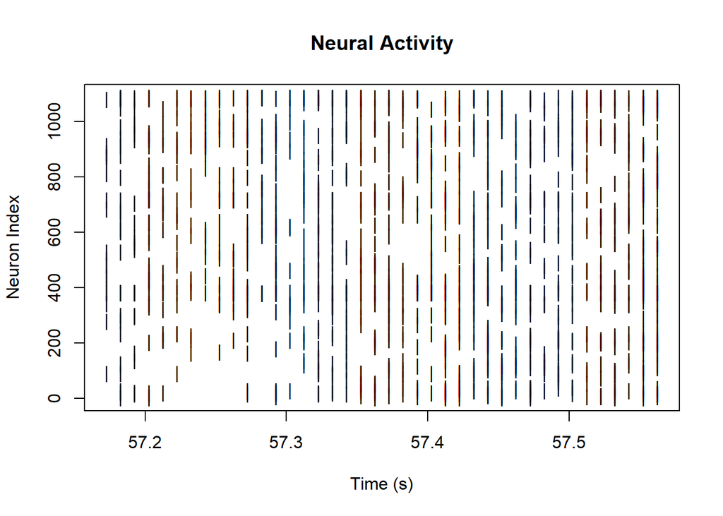

From above plot, session 7,trial 20 and session 18 trial 1 is randomly choose to see the raster plot of neuron and time. The same function can be called for all trials across sessions. From the plot, we can see directly how the neurons active over time during the trial.

### Explore changes over trials

We use heat map as the method to explore changes over trials with in sessions. 18 heat maps are created corresponding each session.Each row in a heat map corresponds to a single trial, while each column represents a time bin within that trial. The color intensity reflects the normalized spike rate, with warmer colors indicating higher levels of neural firing.

In examining all heat maps, we notice several recurring patterns: There are periods of heightened activity that appear consistently across trials, indicating that the neurons are responsive to the visual task given. Session 17 has the highest correctness rate from the previous data exploration, and session 11 has a relatively high correctness rate but we think the pattern is worth analyze, hence we attach the heat map of session 11 and session 17 as follows, we can see a obvious pattern that a large proportion of trials have a similarity in time bins which indicates consistent neural responses to the experimental conditions.

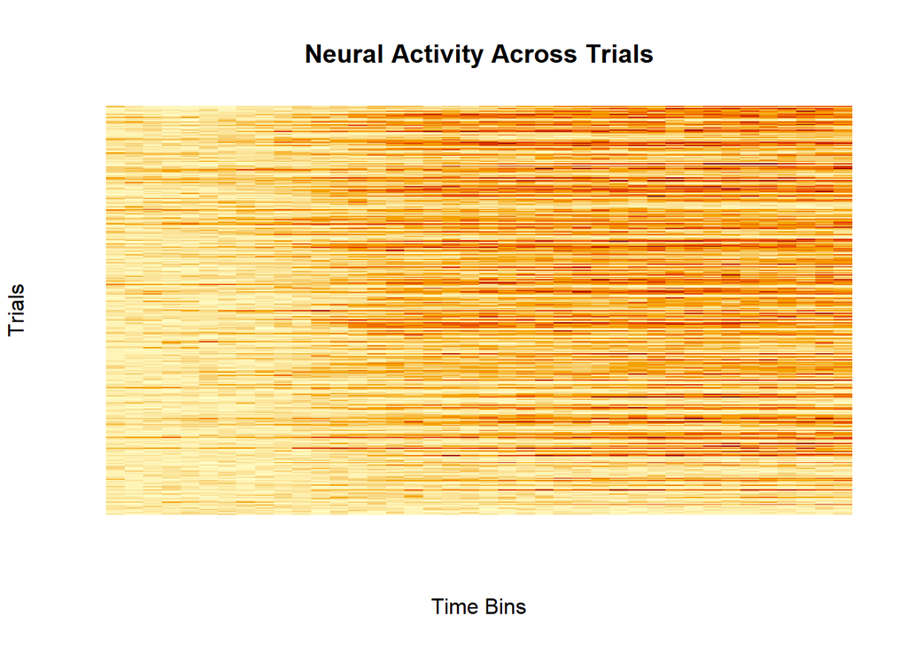

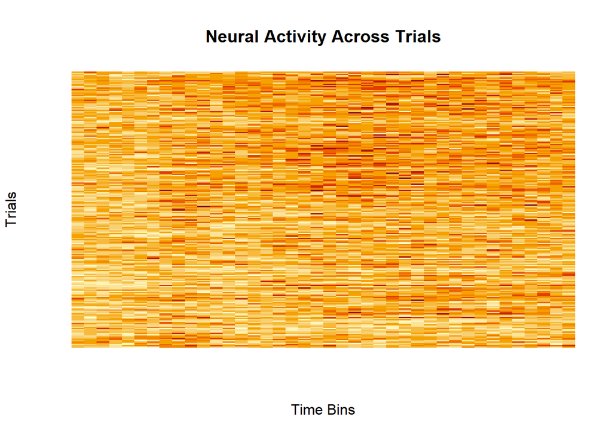